# 01f. Complete-forward ITS2 preprocessing comparison

QC20 / maxEE2 — Cutadapt Single vs ITSxpress Single

2026-10-16

# 1 1. 분석 설계

## 1.1 입력과 비교 범위

- 입력은 `q20_ee22_both_full_cutadapt_forward`의 Cutadapt single 및 ITSxpress single DADA2 feature table과 UNITE v10 99% taxonomy임.
- 두 pipeline 모두 동일한 완전한 forward read와 공통 SampleID 83개를 사용함.
- 첨부한 `01_Preprocessing_2.Rmd`와 동일한 taxonomy 정리 및 `Kingdom == Fungi`/zero-sum 제거 규칙을 적용함.
- abundance threshold, singleton 제거, rarefaction 및 decontam은 적용하지 않음.
- Aitchison은 non-rarefied Species count에 pseudocount 0.5와 CLR을 적용함.
- 색상, control/subject shape, density가 결합된 PCoA, composition palette/facet 및 theme는 `01_Preprocessing_2.Rmd`의 정의를 그대로 사용함.

| Comparison | Method_1 | Method_2 |
| --- | --- | --- |
| Complete forward: Cutadapt vs ITSxpress | Cutadapt Single | ITSxpress Single |

## 1.2 Sample 구성

| Sample_Type | Control_Type | Subject | PCR_Cycle_Group | N |
| --- | --- | --- | --- | --- |
| Control | Air swab | ASwab-C1 | PCR1_33__PCR2_8 | 1 |
| Control | Air swab | ASwab-C1 | PCR1_33__PCR2_10 | 1 |
| Control | Air swab | ASwab-C1 | PCR1_35__PCR2_8 | 1 |
| Control | Air swab | ASwab-C1 | PCR1_35__PCR2_10 | 1 |
| Control | Clean bench swab | CSwab-C1 | PCR1_33__PCR2_8 | 1 |
| Control | Clean bench swab | CSwab-C1 | PCR1_33__PCR2_10 | 1 |
| Control | Clean bench swab | CSwab-C1 | PCR1_35__PCR2_8 | 1 |
| Control | Clean bench swab | CSwab-C1 | PCR1_35__PCR2_10 | 1 |
| Control | Empty tube | ETube-C1 | PCR1_33__PCR2_8 | 1 |
| Control | Empty tube | ETube-C1 | PCR1_33__PCR2_10 | 1 |

[output cut: 10 more lines]

# 2 2. Phyloseq 생성 및 QC

## 2.1 전처리 전후 audit

| Method | Stage | Samples | Taxa | Total_Reads |
| --- | --- | --- | --- | --- |
| Cutadapt Single | Imported ASV table | 83 | 1855 | 1186913 |
| Cutadapt Single | Taxonomy cleaned | 83 | 1855 | 1186913 |
| Cutadapt Single | Kingdom == Fungi retained | 83 | 1855 | 1186913 |
| Cutadapt Single | Zero-sum samples/taxa removed | 83 | 1855 | 1186913 |
| ITSxpress Single | Imported ASV table | 83 | 211 | 115907 |
| ITSxpress Single | Taxonomy cleaned | 83 | 211 | 115907 |
| ITSxpress Single | Kingdom == Fungi retained | 83 | 211 | 115907 |
| ITSxpress Single | Zero-sum samples/taxa removed | 83 | 211 | 115907 |

두 pipeline 모두 83개 sample이 유지됨. 최종 fungal ASV는 Cutadapt Single 1855개, ITSxpress Single 211개임.

| Method | ASV | Kingdom | Phylum | Class | Order | Family | Genus | Species |
| --- | --- | --- | --- | --- | --- | --- | --- | --- |
| Cutadapt Single | 1855 | 1 | 7 | 29 | 84 | 221 | 386 | 572 |
| ITSxpress Single | 211 | 1 | 5 | 15 | 33 | 57 | 94 | 129 |

생성한 phyloseq object:

- Cutadapt complete-forward RDS
- ITSxpress complete-forward RDS

## 2.2 Read depth와 observed ASV

| Method | Sample_Type | N | Min | Q1 | Median | Q3 | Max |
| --- | --- | --- | --- | --- | --- | --- | --- |
| Cutadapt Single | Control | 12 | 1712 | 2220 | 2799 | 4005 | 7312 |
| Cutadapt Single | True | 71 | 1226 | 9073.5 | 16334 | 22034.5 | 44819 |
| ITSxpress Single | Control | 12 | 1 | 1.75 | 3.5 | 26.5 | 373 |
| ITSxpress Single | True | 71 | 2 | 392 | 1439 | 2743.5 | 5821 |

| Comparison | Metric | N_Pairs | Median_Method_1 | Median_Method_2 | Median_Ratio_Method_2_to_1 | P_value | P_adjust_BH |
| --- | --- | --- | --- | --- | --- | --- | --- |
| Complete forward: Cutadapt vs ITSxpress | Read_Depth | 83 | 13873 | 716 | 0.06029422974312067 | 2.549524798426167e-15 | 2.549524798426167e-15 |
| Complete forward: Cutadapt vs ITSxpress | Observed_ASV | 83 | 58 | 12 | 0.189873417721519 | 2.537859497350641e-15 | 2.549524798426167e-15 |

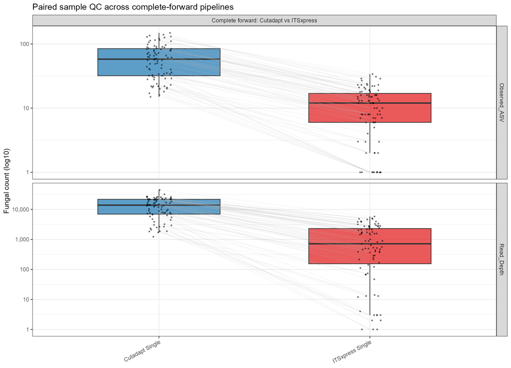

Observed ASV는 rarefaction 통과 여부나 filtering 기준이 아니라, 각 원본 fungal count table에서 sample별 non-zero ASV 수를 그대로 집계한 QC 지표임.

# 3 3. Aitchison beta diversity

## 3.1 Paired method effect

| Comparison | Method_1 | Method_2 | N_Pairs | PERMANOVA_R2 | PERMANOVA_P | Betadisper_P | Procrustes_r | PROTEST_P | PERMANOVA_P_BH | Betadisper_P_BH |
| --- | --- | --- | --- | --- | --- | --- | --- | --- | --- | --- |
| Complete forward: Cutadapt vs ITSxpress | Cutadapt Single | ITSxpress Single | 83 | 0.1952355532653484 | 0.001 | 0.001 | 0.9110081740673076 | 0.001 | 0.001 | 0.001 |

- PERMANOVA permutation은 동일 SampleID 안에 제한함.
- `betadisper`가 유의하면 centroid 이동뿐 아니라 dispersion 차이도 포함할 수 있으므로 순수한 위치 효과로 단정하지 않음.
- Procrustes correlation은 두 pipeline에서 sample 간 배치 구조가 얼마나 보존되는지를 평가함.

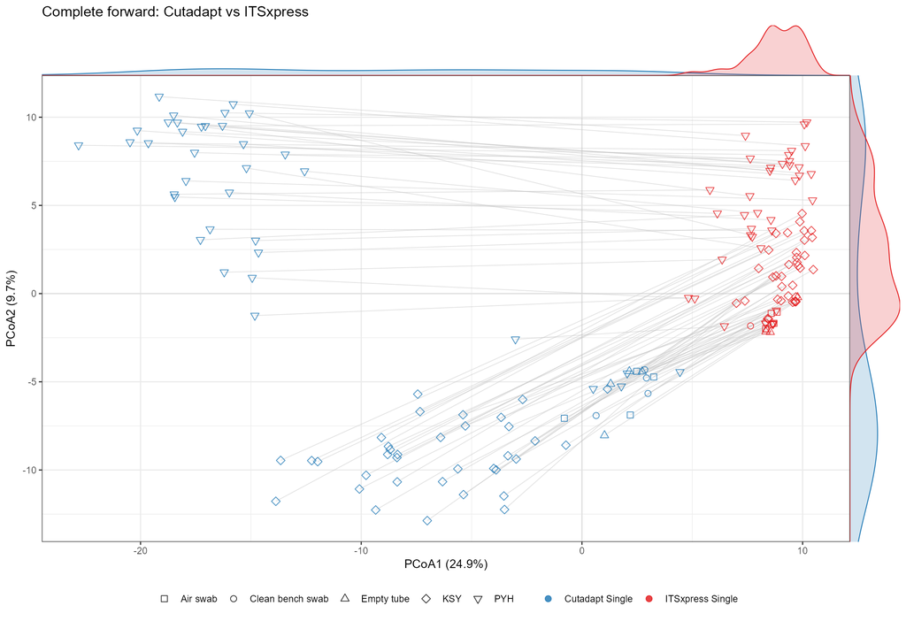

PCoA 위·오른쪽의 density, 방법 색상 및 shape는 `01_Preprocessing_2.Rmd`와 동일하다.

# 4 4. Species-level taxa 비교

## 4.1 Species overlap

| Comparison | Method_1 | Method_2 | Detected_Method_1 | Detected_Method_2 | Shared | Method_1_only | Method_2_only |
| --- | --- | --- | --- | --- | --- | --- | --- |
| Complete forward: Cutadapt vs ITSxpress | Cutadapt Single | ITSxpress Single | 572 | 129 | 94 | 478 | 35 |

## 4.2 Paired abundance difference

각 점은 sample이나 ASV가 아니라 동일 Species fallback label로 합산한 뒤 83개 sample에서 평균한 taxon임. 상위 14 taxa만 이름을 표시함.

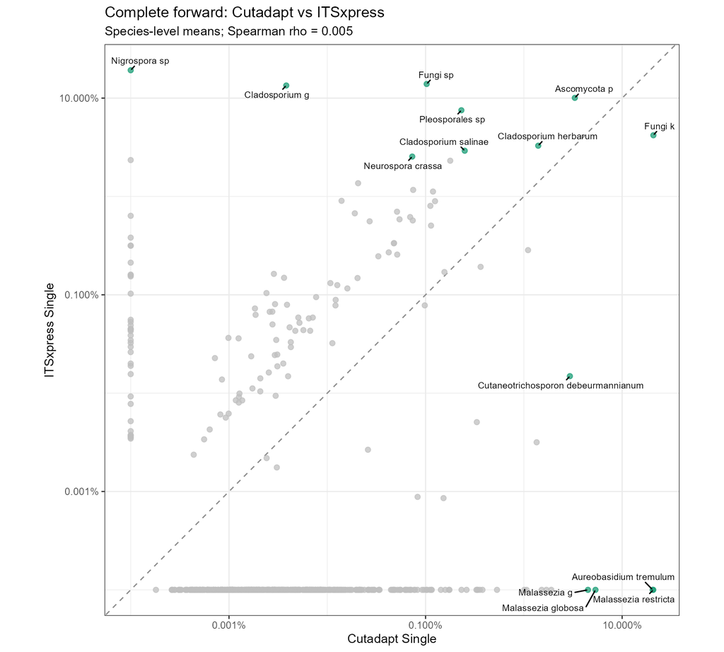

| Species | Comparison | Method_1 | Method_2 | N_Pairs | Mean_Method_1 | Mean_Method_2 | Mean_Difference_2_minus_1 | P_value | P_adjust_BH |
| --- | --- | --- | --- | --- | --- | --- | --- | --- | --- |
| Malassezia restricta | Complete forward: Cutadapt vs ITSxpress | Cutadapt Single | ITSxpress Single | 83 | 0.2074395142340069 | 0 | -0.2074395142340069 | 3.732170303971064e-15 | 5.22503842555949e-14 |
| Aureobasidium tremulum | Complete forward: Cutadapt vs ITSxpress | Cutadapt Single | ITSxpress Single | 83 | 0.2045499188464655 | 0 | -0.2045499188464655 | 1.715161476138479e-14 | 1.200613033296935e-13 |
| Malassezia globosa | Complete forward: Cutadapt vs ITSxpress | Cutadapt Single | ITSxpress Single | 83 | 0.05355299302965659 | 0 | -0.05355299302965659 | 1.14534011850669e-12 | 5.344920553031221e-12 |
| Cutaneotrichosporon debeurmannianum | Complete forward: Cutadapt vs ITSxpress | Cutadapt Single | ITSxpress Single | 83 | 0.02940667488939695 | 0.0001478490973661739 | -0.02925882579203078 | 3.599102325947631e-11 | 8.39790542721114e-11 |
| Malassezia g | Complete forward: Cutadapt vs ITSxpress | Cutadapt Single | ITSxpress Single | 83 | 0.04492232496932955 | 0 | -0.04492232496932955 | 3.599102325947631e-11 | 8.39790542721114e-11 |
| Nigrospora sp | Complete forward: Cutadapt vs ITSxpress | Cutadapt Single | ITSxpress Single | 83 | 0 | 0.1921189496933798 | 0.1921189496933798 | 3.596687839878167e-11 | 8.39790542721114e-11 |
| Cladosporium g | Complete forward: Cutadapt vs ITSxpress | Cutadapt Single | ITSxpress Single | 83 | 3.725110209827263e-05 | 0.1343639696749156 | 0.1343267185728174 | 5.281807291948156e-11 | 1.056361458389631e-10 |
| Pleosporales sp | Complete forward: Cutadapt vs ITSxpress | Cutadapt Single | ITSxpress Single | 83 | 0.002312659523271786 | 0.07524999868657417 | 0.07293733916330238 | 7.388532627047111e-10 | 1.292993209733244e-09 |
| Cladosporium salinae | Complete forward: Cutadapt vs ITSxpress | Cutadapt Single | ITSxpress Single | 83 | 0.002501568777470053 | 0.02916939151373305 | 0.02666782273626299 | 1.683581624664699e-09 | 2.618904749478421e-09 |
| Ascomycota p | Complete forward: Cutadapt vs ITSxpress | Cutadapt Single | ITSxpress Single | 83 | 0.03301014840119362 | 0.1005934430892704 | 0.06758329468807675 | 2.492293254303481e-09 | 3.489210556024873e-09 |

[output cut: 4 more lines]

BH 보정은 상위 14 Species 안에서 수행했으므로 논문용 전체 differential-abundance 검정이 아니라 preprocessing 방법에 따른 주요 조성 변화의 기술적 비교임.

# 5 5. Sample별 Species composition

- 각 막대는 개별 SampleID임.
- 두 그림에 동일한 top Species 목록과 `RColorBrewer` Paired/Dark2 기반 색을 사용함.
- facet은 Subject/control source와 PCR cycle 조합이며 `nrow = 1`로 가로 배치함.
- HTML에는 축소 preview를 표시하고 원본은 42-inch wide PNG로 별도 저장함.

## 5.1 Cutadapt Single

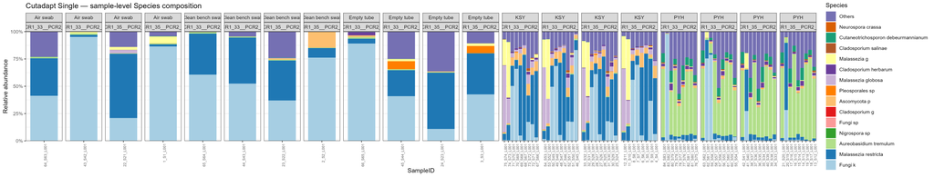

고해상도 PNG 열기

## 5.2 ITSxpress Single

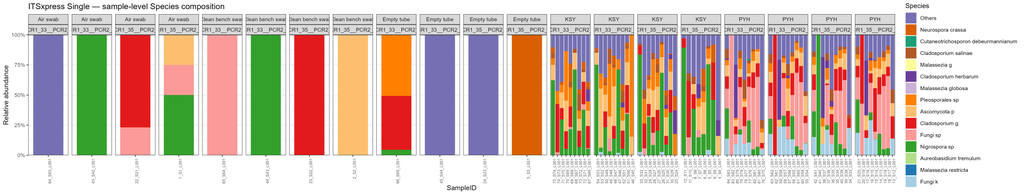

고해상도 PNG 열기

# 6 6. ASV sequence length와 frequency

| Method | ASVs | Median_Length | Q1_Length | Q3_Length | Min_Length | Max_Length | Total_Reads |
| --- | --- | --- | --- | --- | --- | --- | --- |
| Cutadapt Single | 1855 | 281 | 271 | 281 | 50 | 282 | 1186913 |
| ITSxpress Single | 211 | 148 | 141.5 | 152 | 56 | 207 | 115907 |

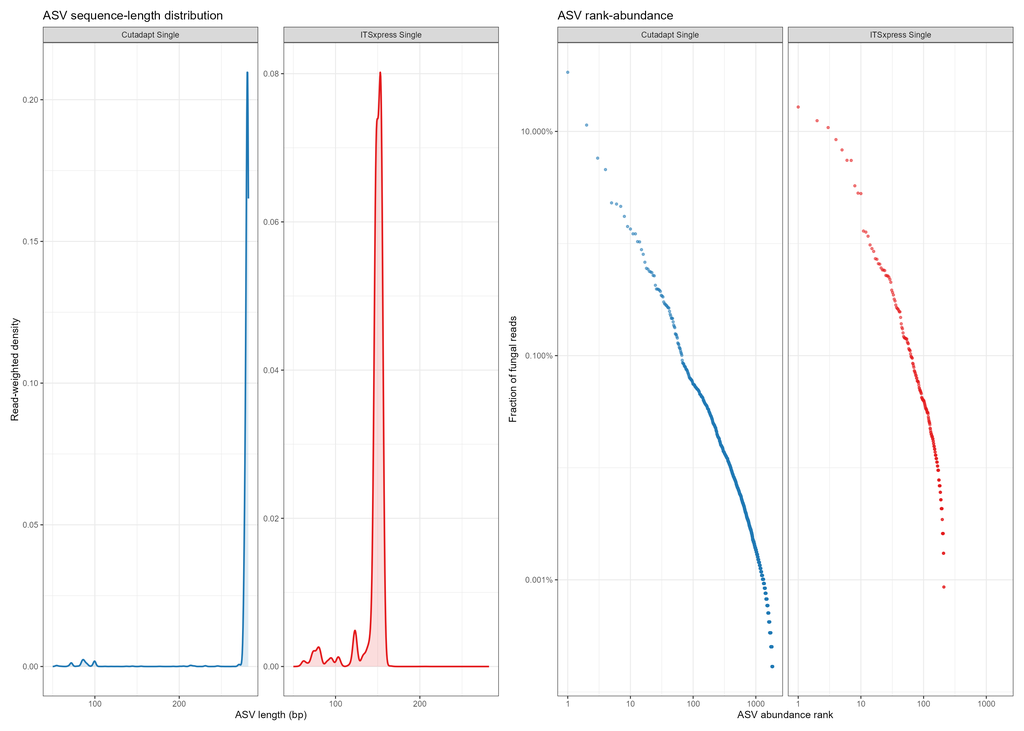

- complete-forward ASV의 최대 길이는 Cutadapt 282 bp, ITSxpress 207 bp임.
- length density는 ASV 개수뿐 아니라 각 ASV의 fungal read 수로 가중함.

## 6.1 BLAST-confirmed Raphanus ASV 확인

| Item | Value |
| --- | --- |
| Cutadapt ASV total reads | 68588 |
| Cutadapt ASV length | 281 |
| ITSxpress contained ASVs | 0 |
| ITSxpress matched reads | 0 |

이 표만 최근 BLAST 결과를 확인하기 위해 추가했으며 기존 시각화 정의는 변경하지 않았다. `5c8f111a2f4a8e9e41a1cb58ebc985f6`와 exact containment 관계인 ITSxpress ASV가 있는지 확인한다.

# 7 7. 종합 요약

- **Complete forward: Cutadapt vs ITSxpress**: paired Aitchison PERMANOVA R² = 0.195, p = 0.001; betadisper p = 0.001; Procrustes r = 0.911.
- 두 방법에서 동일한 83개 sample과 동일한 fungal/zero-sum 처리 규칙을 사용함.
- ITSxpress/Cutadapt read-depth 중앙값 비율은 0.06임.
- Cutadapt Single의 read와 ASV가 더 많다는 사실은 생물학적 다양성 증가를 의미하지 않으며 trimming/HMM boundary 및 denoising 차이를 포함함.
- `betadisper`가 유의한 경우 PERMANOVA 차이의 일부가 dispersion 변화에서 유래할 수 있음.
- 본 보고서는 preprocessing 방법 선택의 기술적 비교이며 decontam이나 biological inference를 수행하지 않음.

# 8 8. 재현 파일

- 전체 분석 R script
- 전체 중간 object RDS
- Beta statistics CSV
- Species paired tests CSV
- ASV sequence summary CSV
- Raphanus ASV check CSV

## 8.1 한계

- rarefaction은 적용하지 않았으며 이 보고서의 Aitchison 분석에는 필요하지 않음.
- Bray–Curtis/Jaccard, alpha diversity 및 decontam은 본 preprocessing 비교에서 수행하지 않음.
- taxa 검정은 compositional dependency와 반복 PCR 구조를 완전히 모형화한 differential-abundance 분석이 아니라 paired descriptive screen임.